# week_14_cv_logistic_statsmodels

## CMPINF 2100 Week 14

### Apply Cross-Validation to Logistic Regression models

We will use statsmodels to FIT and make predictions with logistic regression models.

We will use the same data from Week 13 and FIT all 17 models from Week 13.

We will use CROSS-VALIDATION to estimate the AVERAGE Accuracy on New Data for all 17 models!!!

This CROSS-VALIDATION Accuracy metric will be used to identify the BEST MODEL on NEW data!!!

## Import Modules

```python
import numpy as np
import pandas as pd
import matplotlib.pyplot as plt

import seaborn as sns
```

## Read data

Use the week 13 example.

```python
df = pd.read_csv("../week_13/week_12_binary_classification.csv")
```

```python
df.info()
```

```
<class 'pandas.core.frame.DataFrame'>
RangeIndex: 300 entries, 0 to 299
Data columns (total 6 columns):
 #   Column  Non-Null Count  Dtype
---  ------  --------------  -----
 0   x1      300 non-null    float64
 1   x2      300 non-null    float64
 2   x3      300 non-null    float64
 3   x4      300 non-null    float64
 4   x5      300 non-null    object
 5   y       300 non-null    int64
dtypes: float64(4), int64(1), object(1)
memory usage: 14.2+ KB
```

## Goal

The goal is to use K-fold Cross-Validation to evaluate the performance of the 17 models from last week!!

```python
formula_list = ["y ~ 1",
               "y ~ x5",
               "y ~ x1 + x2 + x3 + x4",
               "y ~ x1 + x2 + x3 + x4 + x5",
               "y ~ x5 * (x1 + x2 + x3 + x4)",
               "y ~ (x1 + x2 + x3 + x4) ** 2",
               "y ~ x1 + x2 + x3 + x4 + np.power(x1, 2) + np.power(x2 ,2) + np.power(x3 ,2) + np.power(x4 ,2)",
               "y ~ x5 + x1 + x2 + x3 + x4 + np.power(x1, 2) + np.power(x2 ,2) + np.power(x3 ,2) + np.power(x4 ,2)",
               "y ~ x5 * (x1 + x2 + x3 + x4 + np.power(x1, 2) + np.power(x2 ,2) + np.power(x3 ,2) + np.power(x4 ,2))",
               "y ~ x5 + ((x1 + x2 + x3 + x4) ** 2 + np.power(x1, 2) + np.power(x2 ,2) + np.power(x3 ,2) + np.power(x4 ,2))",
               "y ~ x5 * ((x1 + x2 + x3 + x4) ** 2 + np.power(x1, 2) + np.power(x2 ,2) + np.power(x3 ,2) + np.power(x4 ,2))",
               "y ~ x5 + (x1 + x2 + x3 + x4) ** 3",
               "y ~ x5 + (x1 + x2 + x3 + x4) ** 4",
               "y ~ (x1 + x2 + x3 + x4 + x5) ** 3",
               "y ~ (x1 + x2 + x3 + x4 + x5) ** 4",
               "y ~ x5 * ( (x1 + x2 + x3 + x4) ** 3 + np.power(x1, 2) + np.power(x2 ,2) + np.power(x3 ,2) + np.power(x4 ,2) + np.power(x1, 3) + np.power(x2 ,3) + np.power(x3 ,3) + np.power(x4 ,3))",
               "y ~ x5 * ( (x1 + x2 + x3 + x4) ** 3 + np.power(x1, 2) + np.power(x2 ,2) + np.power(x3 ,2) + np.power(x4 ,2) + np.power(x1, 3) + np.power(x2 ,3) + np.power(x3 ,3) + np.power(x4 ,3) + np.power(x1, 4) + np.power(x2 ,4) + np.power(x3 ,4) + np.power(x4 ,4))"]
```

```python
len(formula_list)
```

```
17
```

```python
formula_list[0]
```

```
'y ~ 1'
```

```python
type(formula_list)
```

```
list
```

```python
formula_list[3]
```

```
'y ~ x1 + x2 + x3 + x4 + x5'
```

We will use STRATIFIED cross-validation because we are working on a CLASSIFICATION problem.

```python
from sklearn.model_selection import StratifiedKFold
```

Lets use 5-fold CV.

```python
kf = StratifiedKFold(n_splits=5, shuffle=True, random_state=9483156)
```

```python
kf.get_n_splits()
```

```
5
```

We will FIT the logistic regression models using STATSMODELS.

```python
import statsmodels.formula.api as smf
```

We need a few more helper objects that will HELP us execute everything.

We need the COLUMN NAMES for the INPUTS. And we will need the OUTPUT column name.

```python
input_names = df.drop(columns=["y"]).copy().columns.to_list()
```

```python
output_name = "y"
```

Lets define a FUNCTION that manages the FITTING and PERFORMANCE METRIC calcs within the CROSS-VALIDATION FOLDS!!!

Lets focus on the ACCURACY as our performance metric.

```python
def train_and_test_logistic_with_cv(mod_name, a_formula, data_df, x_names, y_name, cv, threshold=0.5):
    # separate the inputs and output
    input_df = data_df.loc[:, x_names].copy()

    # intitialize the performance metric storage lists
    train_res = []
    test_res = []

    # SPLIT the data and iterate over the folds
    for train_id, test_id in cv.split(input_df.to_numpy(), data_df[y_name].to_numpy()):
        # subset the training and test splits within each fold
        train_data = data_df.iloc[train_id, :].copy()
        test_data = data_df.iloc[test_id, :].copy()

        # FIT the model on the TRAINING data within the current FOLD
        a_mod = smf.logit(formula=a_formula, data=train_data).fit()

        # PREDICT the TRAINING within each FOLD
        train_copy = train_data.copy()
        train_copy["pred_probability"] = a_mod.predict(train_data)
        train_copy["pred_class"] = np.where(train_copy.pred_probability > threshold, 1, 0)

        # PREDICT the TEST within each FOLD
        test_copy = test_data.copy()
        test_copy["pred_probability"] = a_mod.predict(test_data)
        test_copy["pred_class"] = np.where(test_copy.pred_probability > threshold, 1, 0)

        # calculate the PERFORMANCE METRIC on the TRAINING SET within each FOLD
        train_res.append(np.mean(train_copy[y_name] == train_copy.pred_class))

        # calculate the PERFORMANCE METRIC on the TESTING SET within each FOLD
        test_res.append(np.mean(test_copy[y_name] == test_copy.pred_class))
    # Book keeping to store the results
    train_df = pd.DataFrame({"Accuracy": train_res})
    train_df["from_set"] = "training"
    train_df["fold_id"] = train_df.index + 1

    test_df = pd.DataFrame({"Accuracy": test_res})
    test_df["from_set"] = "testing"
    test_df["fold_id"] = test_df.index + 1

    # combine the splits together
    res_df = pd.concat([train_df, test_df], ignore_index=True)

    # add information about the model
    res_df["model_name"] = mod_name
    res_df["model_formula"] = a_formula
    res_df["num_coefs"] = len(a_mod.params)
    res_df["threshold"] = threshold


    return res_df
```

Test this function on a single model. Lets use the INTERCEPT ONLY or CONSTANT model!

```python
train_and_test_logistic_with_cv(mod_name=0, a_formula=formula_list[0], data_df=df, x_names=input_names, y_name=output_name, cv=kf, threshold=0.5)
```

```
Optimization terminated successfully.
         Current function value: 0.639363
         Iterations 4
Optimization terminated successfully.
         Current function value: 0.639363
         Iterations 4
Optimization terminated successfully.
         Current function value: 0.642135
         Iterations 4
Optimization terminated successfully.
         Current function value: 0.642135
         Iterations 4
Optimization terminated successfully.
         Current function value: 0.642135
         Iterations 4
```

|  | Accuracy | from_set | fold_id | model_name | model_formula | num_coefs | threshold |
| --- | --- | --- | --- | --- | --- | --- | --- |
| 0 | 0.662500 | training | 1 | 0 | y ~ 1 | 1 | 0.5 |
| 1 | 0.662500 | training | 2 | 0 | y ~ 1 | 1 | 0.5 |
| 2 | 0.658333 | training | 3 | 0 | y ~ 1 | 1 | 0.5 |
| 3 | 0.658333 | training | 4 | 0 | y ~ 1 | 1 | 0.5 |
| 4 | 0.658333 | training | 5 | 0 | y ~ 1 | 1 | 0.5 |
| 5 | 0.650000 | testing | 1 | 0 | y ~ 1 | 1 | 0.5 |
| 6 | 0.650000 | testing | 2 | 0 | y ~ 1 | 1 | 0.5 |
| 7 | 0.666667 | testing | 3 | 0 | y ~ 1 | 1 | 0.5 |
| 8 | 0.666667 | testing | 4 | 0 | y ~ 1 | 1 | 0.5 |
| 9 | 0.666667 | testing | 5 | 0 | y ~ 1 | 1 | 0.5 |

Lets try again on a more complex model!

```python
formula_list[3]
```

```
'y ~ x1 + x2 + x3 + x4 + x5'
```

```python
train_and_test_logistic_with_cv(mod_name=3, a_formula=formula_list[3], data_df=df, x_names=input_names, y_name=output_name, cv=kf, threshold=0.5)
```

```
Optimization terminated successfully.
         Current function value: 0.572898
         Iterations 5
Optimization terminated successfully.
         Current function value: 0.589669
         Iterations 5
Optimization terminated successfully.
         Current function value: 0.582540
         Iterations 5
Optimization terminated successfully.
         Current function value: 0.598348
         Iterations 5
Optimization terminated successfully.
         Current function value: 0.586447
         Iterations 5
```

|  | Accuracy | from_set | fold_id | model_name | model_formula | num_coefs | threshold |
| --- | --- | --- | --- | --- | --- | --- | --- |
| 0 | 0.675000 | training | 1 | 3 | y ~ x1 + x2 + x3 + x4 + x5 | 7 | 0.5 |
| 1 | 0.637500 | training | 2 | 3 | y ~ x1 + x2 + x3 + x4 + x5 | 7 | 0.5 |
| 2 | 0.670833 | training | 3 | 3 | y ~ x1 + x2 + x3 + x4 + x5 | 7 | 0.5 |
| 3 | 0.645833 | training | 4 | 3 | y ~ x1 + x2 + x3 + x4 + x5 | 7 | 0.5 |
| 4 | 0.687500 | training | 5 | 3 | y ~ x1 + x2 + x3 + x4 + x5 | 7 | 0.5 |
| 5 | 0.566667 | testing | 1 | 3 | y ~ x1 + x2 + x3 + x4 + x5 | 7 | 0.5 |
| 6 | 0.700000 | testing | 2 | 3 | y ~ x1 + x2 + x3 + x4 + x5 | 7 | 0.5 |
| 7 | 0.633333 | testing | 3 | 3 | y ~ x1 + x2 + x3 + x4 + x5 | 7 | 0.5 |
| 8 | 0.716667 | testing | 4 | 3 | y ~ x1 + x2 + x3 + x4 + x5 | 7 | 0.5 |
| 9 | 0.600000 | testing | 5 | 3 | y ~ x1 + x2 + x3 + x4 + x5 | 7 | 0.5 |

What about an EVEN MORE complex model??

```python
formula_list[14]
```

```
'y ~ (x1 + x2 + x3 + x4 + x5) ** 4'
```

```python
train_and_test_logistic_with_cv(mod_name=14, a_formula=formula_list[14], data_df=df, x_names=input_names, y_name=output_name, cv=kf, threshold=0.5)
```

```
Optimization terminated successfully.
         Current function value: 0.481118
         Iterations 8
Optimization terminated successfully.
         Current function value: 0.468108
         Iterations 7
Optimization terminated successfully.
         Current function value: 0.473089
         Iterations 8
Optimization terminated successfully.
         Current function value: 0.497845
         Iterations 7
Optimization terminated successfully.
         Current function value: 0.460337
         Iterations 8
```

|  | Accuracy | from_set | fold_id | model_name | model_formula | num_coefs | threshold |
| --- | --- | --- | --- | --- | --- | --- | --- |
| 0 | 0.745833 | training | 1 | 14 | y ~ (x1 + x2 + x3 + x4 + x5) ** 4 | 46 | 0.5 |
| 1 | 0.775000 | training | 2 | 14 | y ~ (x1 + x2 + x3 + x4 + x5) ** 4 | 46 | 0.5 |
| 2 | 0.754167 | training | 3 | 14 | y ~ (x1 + x2 + x3 + x4 + x5) ** 4 | 46 | 0.5 |
| 3 | 0.745833 | training | 4 | 14 | y ~ (x1 + x2 + x3 + x4 + x5) ** 4 | 46 | 0.5 |
| 4 | 0.758333 | training | 5 | 14 | y ~ (x1 + x2 + x3 + x4 + x5) ** 4 | 46 | 0.5 |
| 5 | 0.633333 | testing | 1 | 14 | y ~ (x1 + x2 + x3 + x4 + x5) ** 4 | 46 | 0.5 |
| 6 | 0.600000 | testing | 2 | 14 | y ~ (x1 + x2 + x3 + x4 + x5) ** 4 | 46 | 0.5 |
| 7 | 0.566667 | testing | 3 | 14 | y ~ (x1 + x2 + x3 + x4 + x5) ** 4 | 46 | 0.5 |
| 8 | 0.650000 | testing | 4 | 14 | y ~ (x1 + x2 + x3 + x4 + x5) ** 4 | 46 | 0.5 |
| 9 | 0.533333 | testing | 5 | 14 | y ~ (x1 + x2 + x3 + x4 + x5) ** 4 | 46 | 0.5 |

The model with a large number of coefficients that need estimated has **WORSE** test set performance than training set performance!!

Lets now apply a 5-fold CV to ALL 17 models which range from SIMPLE to VERY COMPLEX.

## Execute Cross-Validation

```python
results_list = []

for m in range(len(formula_list)):
    print("-- Formula ID %d --" % m)

    results_list.append(train_and_test_logistic_with_cv(mod_name=m, a_formula=formula_list[m], data_df=df, x_names=input_names,
                                                        y_name=output_name, cv=kf, threshold=0.5))
```

[output not shown]

[output cut: 208 more lines]

```
         Current function value: 0.327291
         Iterations 14
Optimization terminated successfully.
         Current function value: 0.338815
         Iterations 13
Optimization terminated successfully.
         Current function value: 0.330479
         Iterations 11
-- Formula ID 16 --
Optimization terminated successfully.
         Current function value: 0.295126
         Iterations 17
Warning: Maximum number of iterations has been exceeded.
         Current function value: inf
         Iterations: 35
```

[output not shown]

How can we overcome this ERROR???

Lets use a very simple strategy, lets use a TRY/EXCEPT procedure.

This strategy involved TRYING something and then if an ERROR or EXCEPTION is raised you print a message.

```python
results_list = []

for m in range(len(formula_list)):
    print("-- Formula ID %d --" % m)

    try:
        results_list.append(train_and_test_logistic_with_cv(mod_name=m, a_formula=formula_list[m], data_df=df, x_names=input_names,
                                                    y_name=output_name, cv=kf, threshold=0.5))
    except:
        # what happens if there is an error
        print("!!! Formula ID %d could NOT fit !!!" % m)
```

[output not shown]

[output cut: 209 more lines]

```
         Iterations 14
Optimization terminated successfully.
         Current function value: 0.338815
         Iterations 13
Optimization terminated successfully.
         Current function value: 0.330479
         Iterations 11
-- Formula ID 16 --
Optimization terminated successfully.
         Current function value: 0.295126
         Iterations 17
Warning: Maximum number of iterations has been exceeded.
         Current function value: inf
         Iterations: 35
!!! Formula ID 16 could NOT fit !!!
```

```python
len(results_list)
```

```
16
```

```python
len(formula_list)
```

```
17
```

This means, our last FORMULA which COULD FIT on the ENTIRE data set...does **NOT** work if we SPLIT the data!!!!

Combine the results for all models that DID work!

```python
cv_results = pd.concat(results_list, ignore_index=True)
```

```python
cv_results
```

|  | Accuracy | from_set | fold_id | model_name | model_formula | num_coefs | threshold |
| --- | --- | --- | --- | --- | --- | --- | --- |
| 0 | 0.662500 | training | 1 | 0 | y ~ 1 | 1 | 0.5 |
| 1 | 0.662500 | training | 2 | 0 | y ~ 1 | 1 | 0.5 |
| 2 | 0.658333 | training | 3 | 0 | y ~ 1 | 1 | 0.5 |
| 3 | 0.658333 | training | 4 | 0 | y ~ 1 | 1 | 0.5 |
| 4 | 0.658333 | training | 5 | 0 | y ~ 1 | 1 | 0.5 |
| ... | ... | ... | ... | ... | ... | ... | ... |
| 155 | 0.666667 | testing | 1 | 15 | y ~ x5 * ( (x1 + x2 + x3 + x4) ** 3 + np.power... | 69 | 0.5 |
| 156 | 0.633333 | testing | 2 | 15 | y ~ x5 * ( (x1 + x2 + x3 + x4) ** 3 + np.power... | 69 | 0.5 |
| 157 | 0.600000 | testing | 3 | 15 | y ~ x5 * ( (x1 + x2 + x3 + x4) ** 3 + np.power... | 69 | 0.5 |
| 158 | 0.616667 | testing | 4 | 15 | y ~ x5 * ( (x1 + x2 + x3 + x4) ** 3 + np.power... | 69 | 0.5 |
| 159 | 0.633333 | testing | 5 | 15 | y ~ x5 * ( (x1 + x2 + x3 + x4) ** 3 + np.power... | 69 | 0.5 |

160 rows × 7 columns

```python
cv_results.model_name.value_counts()
```

```
model_name
0     10
1     10
2     10
3     10
4     10
5     10
6     10
7     10
8     10
9     10
10    10
11    10
12    10
13    10
14    10
15    10
Name: count, dtype: int64
```

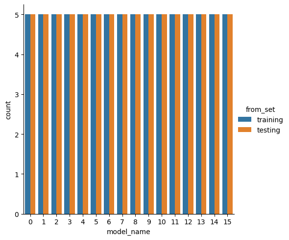

```python
sns.catplot(data=cv_results, x="model_name", hue="from_set", kind="count")
plt.show()
```

Lets look at the ACCURACY values for each model in each fold.

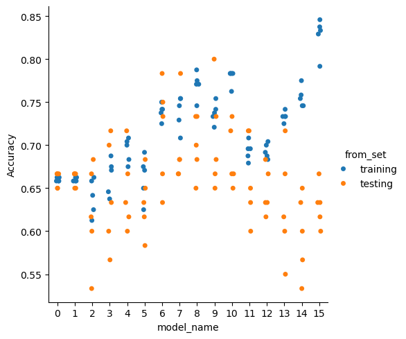

```python
sns.catplot(data=cv_results, x="model_name", y="Accuracy", hue="from_set")

plt.show()
```

Instead, we typically concerned with the AVERAGE performance!!

But I will first overlay the AVERAGE with the FOLD results.

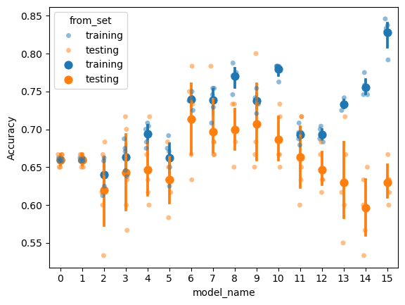

```python
fig, ax = plt.subplots()

sns.stripplot(data=cv_results, x="model_name", y="Accuracy", hue="from_set", ax=ax, alpha=0.5)

sns.pointplot(data=cv_results, x="model_name", y="Accuracy", hue="from_set", join=False, ax=ax)

plt.show()
```

Lets just focus on the AVERAGE so summarize the cross-validation results using a POINT PLOT!

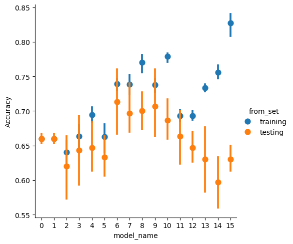

```python
sns.catplot(data=cv_results, x="model_name", y="Accuracy", kind="point", join=False, hue="from_set")

plt.show()
```

More frequently though, and in practice, above figure ONLY shows the TEST SET performance!!!

The POINT PLOT shows the 95% CI by default, but when COMPARING MODELS the convention is to show the 68% CI because that corresponds to the 1 standard error interval!

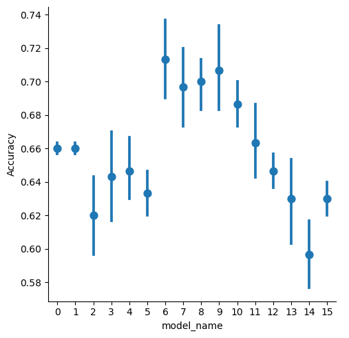

```python
sns.catplot(data=cv_results.loc[cv_results.from_set=="testing", :], x="model_name", y="Accuracy", kind="point", linestyle="none",
           errorbar=("ci", 68))

plt.show()
```

One standard error rule choose the SIMPLEST BEST model!!!

Lets confirm the performance based on the number of coefficients.

```python
cv_results
```

|  | Accuracy | from_set | fold_id | model_name | model_formula | num_coefs | threshold |
| --- | --- | --- | --- | --- | --- | --- | --- |
| 0 | 0.662500 | training | 1 | 0 | y ~ 1 | 1 | 0.5 |
| 1 | 0.662500 | training | 2 | 0 | y ~ 1 | 1 | 0.5 |
| 2 | 0.658333 | training | 3 | 0 | y ~ 1 | 1 | 0.5 |
| 3 | 0.658333 | training | 4 | 0 | y ~ 1 | 1 | 0.5 |
| 4 | 0.658333 | training | 5 | 0 | y ~ 1 | 1 | 0.5 |
| ... | ... | ... | ... | ... | ... | ... | ... |
| 155 | 0.666667 | testing | 1 | 15 | y ~ x5 * ( (x1 + x2 + x3 + x4) ** 3 + np.power... | 69 | 0.5 |
| 156 | 0.633333 | testing | 2 | 15 | y ~ x5 * ( (x1 + x2 + x3 + x4) ** 3 + np.power... | 69 | 0.5 |
| 157 | 0.600000 | testing | 3 | 15 | y ~ x5 * ( (x1 + x2 + x3 + x4) ** 3 + np.power... | 69 | 0.5 |
| 158 | 0.616667 | testing | 4 | 15 | y ~ x5 * ( (x1 + x2 + x3 + x4) ** 3 + np.power... | 69 | 0.5 |
| 159 | 0.633333 | testing | 5 | 15 | y ~ x5 * ( (x1 + x2 + x3 + x4) ** 3 + np.power... | 69 | 0.5 |

160 rows × 7 columns

```python
cv_results.loc[cv_results.from_set=="testing"].model_name.unique()
```

```
array([ 0,  1,  2,  3,  4,  5,  6,  7,  8,  9, 10, 11, 12, 13, 14, 15])
```

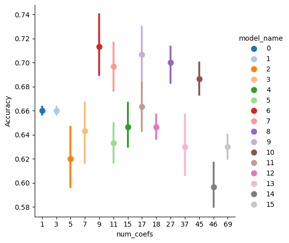

```python
sns.catplot(data=cv_results.loc[cv_results.from_set == "testing", :],
            x="num_coefs",
            y="Accuracy",
            kind="point",
            join=False,
            hue="model_name",
            errorbar=("ci", 68),
           palette="tab20")

plt.show()
```

```python
formula_list[6]
```

```
'y ~ x1 + x2 + x3 + x4 + np.power(x1, 2) + np.power(x2 ,2) + np.power(x3 ,2) + np.power(x4 ,2)'
```

## Model Selection

Choose the model that does the BEST **on average** on NEW data!!!

We must FIT the model one final time using the ENTIRE data set!!!

```python
best_model = smf.logit(formula=formula_list[6], data=df).fit()
```

```
Optimization terminated successfully.
         Current function value: 0.513238
         Iterations 7
```

```python
best_model.pvalues
```

```
Intercept          0.338912
x1                 0.004308
x2                 0.000001
x3                 0.187990
x4                 0.863938
np.power(x1, 2)    0.000028
np.power(x2, 2)    0.000145
np.power(x3, 2)    0.113546
np.power(x4, 2)    0.141733
dtype: float64
```

```python
np.abs(best_model.params[best_model.pvalues < 0.05]).sort_values(ascending=False)
```

```
x2                 0.988749
np.power(x1, 2)    0.683793
np.power(x2, 2)    0.623668
x1                 0.510771
dtype: float64
```

You can use the above approach to idenfity the RANKING of the FEATURES when the INPUTS are STANDARDIZED!!!

VISUALIZE the PREDICTIVE trends for the INPUTS.

```python
input_grid = pd.DataFrame([(x1, x2, x3, x4, x5) for x1 in np.linspace(df.x1.min(), df.x1.max(), num=101)
                                            for x2 in np.linspace(df.x2.min(), df.x2.max(), num=9)
                                            for x3 in [df.x3.mean()]
                                            for x4 in [df.x4.mean()]
                                            for x5 in df.x5.unique()],
                         columns=["x1", "x2", "x3", "x4", "x5"])
```

```python
input_grid.nunique()
```

```
x1    101
x2      9
x3      1
x4      1
x5      3
dtype: int64
```

```python
dfviz = input_grid.copy()
```

```python
dfviz["pred_probability"] = best_model.predict(input_grid)
```

```python
dfviz
```

|  | x1 | x2 | x3 | x4 | x5 | pred_probability |
| --- | --- | --- | --- | --- | --- | --- |
| 0 | -2.913116 | -3.008946 | 0.002302 | 0.001372 | c | 0.000060 |
| 1 | -2.913116 | -3.008946 | 0.002302 | 0.001372 | b | 0.000060 |
| 2 | -2.913116 | -3.008946 | 0.002302 | 0.001372 | a | 0.000060 |
| 3 | -2.913116 | -2.242719 | 0.002302 | 0.001372 | c | 0.000343 |
| 4 | -2.913116 | -2.242719 | 0.002302 | 0.001372 | b | 0.000343 |
| ... | ... | ... | ... | ... | ... | ... |
| 2722 | 2.783826 | 2.354646 | 0.002302 | 0.001372 | b | 0.000080 |
| 2723 | 2.783826 | 2.354646 | 0.002302 | 0.001372 | a | 0.000080 |
| 2724 | 2.783826 | 3.120873 | 0.002302 | 0.001372 | c | 0.000003 |
| 2725 | 2.783826 | 3.120873 | 0.002302 | 0.001372 | b | 0.000003 |
| 2726 | 2.783826 | 3.120873 | 0.002302 | 0.001372 | a | 0.000003 |

2727 rows × 6 columns

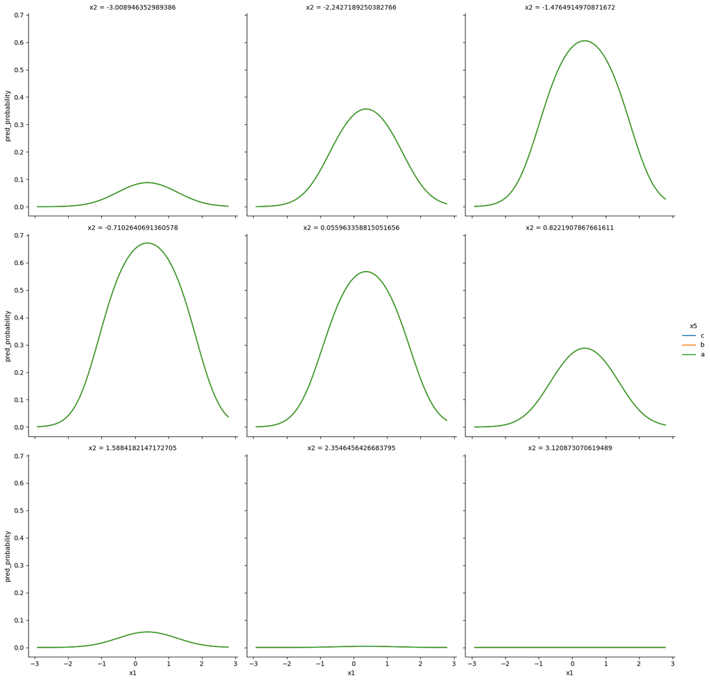

```python
sns.relplot(data=dfviz, x="x1", y="pred_probability", hue="x5", col="x2", kind="line", estimator=None, units="x5",
            col_wrap=3)

plt.show()
```